# Ford GoBike (201902) Exploration

## Preliminary Wrangling

> This dataset (FordGoBike 201902) includes information about individual rides made in a bike-sharing system covering the greater San Francisco Bay area.

> [Bay Wheels (Formerly Ford GoBike)](https://en.wikipedia.org/wiki/Bay_Wheels) is a regional public bicycle sharing system in California's San Francisco Bay Area. It is operated by Motivate in a partnership with the Metropolitan Transportation Commission and the Bay Area Air Quality Management District. Bay Wheels is 'the first regional and large-scale bicycle sharing system deployed in California and on the West Coast of the United States. It was established as Bay Area Bike Share in August 2013. As of January 2018, the Bay Wheels system had over 2,600 bicycles in 262 stations across San Francisco, East Bay and San Jose.

> In June 2017 the system was officially re-launched as Ford GoBike in a partnership with Ford Motor Company. After Motivate's acquisition by Lyft, the system was renamed to Bay Wheels in June 2019. The system is expected to expand to 7,000 bicycles around 540 stations in San Francisco, Oakland, Berkeley, Emeryville, and San Jose.

```python
# Import all packages and set plots to be embedded inline
import numpy as np
import pandas as pd
import matplotlib.pyplot as plt
import seaborn as sns

%matplotlib inline
```

```python
# Import the data
df = pd.read_csv('201902-fordgobike-tripdata.csv')
df.head()
```

|  | duration_sec | start_time | end_time | start_station_id | start_station_name | start_station_latitude | start_station_longitude | end_station_id | end_station_name | end_station_latitude | end_station_longitude | bike_id | user_type | member_birth_year | member_gender | bike_share_for_all_trip |
| --- | --- | --- | --- | --- | --- | --- | --- | --- | --- | --- | --- | --- | --- | --- | --- | --- |
| 0 | 52185 | 2019-02-28 17:32:10.1450 | 2019-03-01 08:01:55.9750 | 21.0 | Montgomery St BART Station (Market St at 2nd St) | 37.789625 | -122.400811 | 13.0 | Commercial St at Montgomery St | 37.794231 | -122.402923 | 4902 | Customer | 1984.0 | Male | No |
| 1 | 42521 | 2019-02-28 18:53:21.7890 | 2019-03-01 06:42:03.0560 | 23.0 | The Embarcadero at Steuart St | 37.791464 | -122.391034 | 81.0 | Berry St at 4th St | 37.775880 | -122.393170 | 2535 | Customer | NaN | NaN | No |
| 2 | 61854 | 2019-02-28 12:13:13.2180 | 2019-03-01 05:24:08.1460 | 86.0 | Market St at Dolores St | 37.769305 | -122.426826 | 3.0 | Powell St BART Station (Market St at 4th St) | 37.786375 | -122.404904 | 5905 | Customer | 1972.0 | Male | No |
| 3 | 36490 | 2019-02-28 17:54:26.0100 | 2019-03-01 04:02:36.8420 | 375.0 | Grove St at Masonic Ave | 37.774836 | -122.446546 | 70.0 | Central Ave at Fell St | 37.773311 | -122.444293 | 6638 | Subscriber | 1989.0 | Other | No |
| 4 | 1585 | 2019-02-28 23:54:18.5490 | 2019-03-01 00:20:44.0740 | 7.0 | Frank H Ogawa Plaza | 37.804562 | -122.271738 | 222.0 | 10th Ave at E 15th St | 37.792714 | -122.248780 | 4898 | Subscriber | 1974.0 | Male | Yes |

```python
# Check out the dimensions of the dataset
df.shape
```

```
(183412, 16)
```

```python
df.info()
```

```
<class 'pandas.core.frame.DataFrame'>
RangeIndex: 183412 entries, 0 to 183411
Data columns (total 16 columns):
 #   Column                   Non-Null Count   Dtype
---  ------                   --------------   -----
 0   duration_sec             183412 non-null  int64
 1   start_time               183412 non-null  object
 2   end_time                 183412 non-null  object
 3   start_station_id         183215 non-null  float64
 4   start_station_name       183215 non-null  object
 5   start_station_latitude   183412 non-null  float64
 6   start_station_longitude  183412 non-null  float64
 7   end_station_id           183215 non-null  float64
 8   end_station_name         183215 non-null  object
 9   end_station_latitude     183412 non-null  float64
 10  end_station_longitude    183412 non-null  float64
 11  bike_id                  183412 non-null  int64
 12  user_type                183412 non-null  object
 13  member_birth_year        175147 non-null  float64
 14  member_gender            175147 non-null  object
 15  bike_share_for_all_trip  183412 non-null  object
dtypes: float64(7), int64(2), object(7)
memory usage: 22.4+ MB
```

```python
# Check for columns with missing data
df.isnull().sum()
```

```
duration_sec                  0
start_time                    0
end_time                      0
start_station_id            197
start_station_name          197
start_station_latitude        0
start_station_longitude       0
end_station_id              197
end_station_name            197
end_station_latitude          0
end_station_longitude         0
bike_id                       0
user_type                     0
member_birth_year          8265
member_gender              8265
bike_share_for_all_trip       0
dtype: int64
```

```python
df.describe()
```

|  | duration_sec | start_station_id | start_station_latitude | start_station_longitude | end_station_id | end_station_latitude | end_station_longitude | bike_id | member_birth_year |
| --- | --- | --- | --- | --- | --- | --- | --- | --- | --- |
| count | 183412.000000 | 183215.000000 | 183412.000000 | 183412.000000 | 183215.000000 | 183412.000000 | 183412.000000 | 183412.000000 | 175147.000000 |
| mean | 726.078435 | 138.590427 | 37.771223 | -122.352664 | 136.249123 | 37.771427 | -122.352250 | 4472.906375 | 1984.806437 |
| std | 1794.389780 | 111.778864 | 0.099581 | 0.117097 | 111.515131 | 0.099490 | 0.116673 | 1664.383394 | 10.116689 |
| min | 61.000000 | 3.000000 | 37.317298 | -122.453704 | 3.000000 | 37.317298 | -122.453704 | 11.000000 | 1878.000000 |
| 25% | 325.000000 | 47.000000 | 37.770083 | -122.412408 | 44.000000 | 37.770407 | -122.411726 | 3777.000000 | 1980.000000 |
| 50% | 514.000000 | 104.000000 | 37.780760 | -122.398285 | 100.000000 | 37.781010 | -122.398279 | 4958.000000 | 1987.000000 |
| 75% | 796.000000 | 239.000000 | 37.797280 | -122.286533 | 235.000000 | 37.797320 | -122.288045 | 5502.000000 | 1992.000000 |
| max | 85444.000000 | 398.000000 | 37.880222 | -121.874119 | 398.000000 | 37.880222 | -121.874119 | 6645.000000 | 2001.000000 |

> The member_birth_year has a minimum of 1878. This is highly unlikly and an outlier which we would have to drop subsequently from our dataset.

```python
df.tail()
```

|  | duration_sec | start_time | end_time | start_station_id | start_station_name | start_station_latitude | start_station_longitude | end_station_id | end_station_name | end_station_latitude | end_station_longitude | bike_id | user_type | member_birth_year | member_gender | bike_share_for_all_trip |
| --- | --- | --- | --- | --- | --- | --- | --- | --- | --- | --- | --- | --- | --- | --- | --- | --- |
| 183407 | 480 | 2019-02-01 00:04:49.7240 | 2019-02-01 00:12:50.0340 | 27.0 | Beale St at Harrison St | 37.788059 | -122.391865 | 324.0 | Union Square (Powell St at Post St) | 37.788300 | -122.408531 | 4832 | Subscriber | 1996.0 | Male | No |
| 183408 | 313 | 2019-02-01 00:05:34.7440 | 2019-02-01 00:10:48.5020 | 21.0 | Montgomery St BART Station (Market St at 2nd St) | 37.789625 | -122.400811 | 66.0 | 3rd St at Townsend St | 37.778742 | -122.392741 | 4960 | Subscriber | 1984.0 | Male | No |
| 183409 | 141 | 2019-02-01 00:06:05.5490 | 2019-02-01 00:08:27.2200 | 278.0 | The Alameda at Bush St | 37.331932 | -121.904888 | 277.0 | Morrison Ave at Julian St | 37.333658 | -121.908586 | 3824 | Subscriber | 1990.0 | Male | Yes |
| 183410 | 139 | 2019-02-01 00:05:34.3600 | 2019-02-01 00:07:54.2870 | 220.0 | San Pablo Ave at MLK Jr Way | 37.811351 | -122.273422 | 216.0 | San Pablo Ave at 27th St | 37.817827 | -122.275698 | 5095 | Subscriber | 1988.0 | Male | No |
| 183411 | 271 | 2019-02-01 00:00:20.6360 | 2019-02-01 00:04:52.0580 | 24.0 | Spear St at Folsom St | 37.789677 | -122.390428 | 37.0 | 2nd St at Folsom St | 37.785000 | -122.395936 | 1057 | Subscriber | 1989.0 | Male | No |

```python
df.user_type.unique()
```

```
array(['Customer', 'Subscriber'], dtype=object)
```

```python
df.user_type.value_counts()
```

```
Subscriber    163544
Customer       19868
Name: user_type, dtype: int64
```

```python
df.member_gender.value_counts()
```

```
Male      130651
Female     40844
Other       3652
Name: member_gender, dtype: int64
```

```python
df.member_gender.unique()
```

```
array(['Male', nan, 'Other', 'Female'], dtype=object)
```

```python
df.columns
```

```
Index(['duration_sec', 'start_time', 'end_time', 'start_station_id',
       'start_station_name', 'start_station_latitude',
       'start_station_longitude', 'end_station_id', 'end_station_name',
       'end_station_latitude', 'end_station_longitude', 'bike_id', 'user_type',
       'member_birth_year', 'member_gender', 'bike_share_for_all_trip'],
      dtype='object')
```

```python
df.size
```

```
2934592
```

```python
#Drop rows with missing data in the member_gender column
df_new = df[df.member_gender.isnull() == False]
df_new.info()
```

```
<class 'pandas.core.frame.DataFrame'>
Int64Index: 175147 entries, 0 to 183411
Data columns (total 16 columns):
 #   Column                   Non-Null Count   Dtype
---  ------                   --------------   -----
 0   duration_sec             175147 non-null  int64
 1   start_time               175147 non-null  object
 2   end_time                 175147 non-null  object
 3   start_station_id         174952 non-null  float64
 4   start_station_name       174952 non-null  object
 5   start_station_latitude   175147 non-null  float64
 6   start_station_longitude  175147 non-null  float64
 7   end_station_id           174952 non-null  float64
 8   end_station_name         174952 non-null  object
 9   end_station_latitude     175147 non-null  float64
 10  end_station_longitude    175147 non-null  float64
 11  bike_id                  175147 non-null  int64
 12  user_type                175147 non-null  object
 13  member_birth_year        175147 non-null  float64
 14  member_gender            175147 non-null  object
 15  bike_share_for_all_trip  175147 non-null  object
dtypes: float64(7), int64(2), object(7)
memory usage: 22.7+ MB
```

```python
df_new.member_gender.unique()
```

```
array(['Male', 'Other', 'Female'], dtype=object)
```

```python
#Drop rows with missing data in the start_station_id column
df_new = df_new[df_new.start_station_id.isnull() == False]
df_new.info()
```

```
<class 'pandas.core.frame.DataFrame'>
Int64Index: 174952 entries, 0 to 183411
Data columns (total 16 columns):
 #   Column                   Non-Null Count   Dtype
---  ------                   --------------   -----
 0   duration_sec             174952 non-null  int64
 1   start_time               174952 non-null  object
 2   end_time                 174952 non-null  object
 3   start_station_id         174952 non-null  float64
 4   start_station_name       174952 non-null  object
 5   start_station_latitude   174952 non-null  float64
 6   start_station_longitude  174952 non-null  float64
 7   end_station_id           174952 non-null  float64
 8   end_station_name         174952 non-null  object
 9   end_station_latitude     174952 non-null  float64
 10  end_station_longitude    174952 non-null  float64
 11  bike_id                  174952 non-null  int64
 12  user_type                174952 non-null  object
 13  member_birth_year        174952 non-null  float64
 14  member_gender            174952 non-null  object
 15  bike_share_for_all_trip  174952 non-null  object
dtypes: float64(7), int64(2), object(7)
memory usage: 22.7+ MB
```

```python
#Check for any duplicates
df_new.duplicated().sum()
```

```
0
```

```python
#Convert the columns to the datetime
df_new['start_time'] = pd.to_datetime(df_new['start_time'])
df_new['end_time'] = pd.to_datetime(df_new['end_time'])
```

```python
df_new.info()
```

```
<class 'pandas.core.frame.DataFrame'>
Int64Index: 174952 entries, 0 to 183411
Data columns (total 16 columns):
 #   Column                   Non-Null Count   Dtype
---  ------                   --------------   -----
 0   duration_sec             174952 non-null  int64
 1   start_time               174952 non-null  datetime64[ns]
 2   end_time                 174952 non-null  datetime64[ns]
 3   start_station_id         174952 non-null  float64
 4   start_station_name       174952 non-null  object
 5   start_station_latitude   174952 non-null  float64
 6   start_station_longitude  174952 non-null  float64
 7   end_station_id           174952 non-null  float64
 8   end_station_name         174952 non-null  object
 9   end_station_latitude     174952 non-null  float64
 10  end_station_longitude    174952 non-null  float64
 11  bike_id                  174952 non-null  int64
 12  user_type                174952 non-null  object
 13  member_birth_year        174952 non-null  float64
 14  member_gender            174952 non-null  object
 15  bike_share_for_all_trip  174952 non-null  object
dtypes: datetime64[ns](2), float64(7), int64(2), object(5)
memory usage: 22.7+ MB
```

```python
# We can now extract the week days and hours information from the start_time
df_new['start_time_dayofweek']= df_new['start_time'].dt.strftime('%a')
df_new['start_time_hour']= df_new['start_time'].dt.hour
```

```python
# Check out the new columns created
df_new[['start_time_dayofweek', 'start_time_hour']].tail()
```

|  | start_time_dayofweek | start_time_hour |
| --- | --- | --- |
| 183407 | Fri | 0 |
| 183408 | Fri | 0 |
| 183409 | Fri | 0 |
| 183410 | Fri | 0 |
| 183411 | Fri | 0 |

```python
# Get the value counts for each day
df_new.start_time_dayofweek.value_counts()
```

```
Thu    33712
Tue    30584
Wed    28426
Fri    27663
Mon    25641
Sun    14512
Sat    14414
Name: start_time_dayofweek, dtype: int64
```

```python
# This transformation converts the start_time_dayofweek to ordinal variables.
week_days = ['Mon','Tue','Wed','Thu','Fri', 'Sat', 'Sun']
ordered_week_days = pd.api.types.CategoricalDtype(ordered = True, categories = week_days)
df_new['start_time_dayofweek'] = df_new['start_time_dayofweek'].astype(ordered_week_days)
```

```python
df_new.info()
```

```
<class 'pandas.core.frame.DataFrame'>
Int64Index: 174952 entries, 0 to 183411
Data columns (total 18 columns):
 #   Column                   Non-Null Count   Dtype
---  ------                   --------------   -----
 0   duration_sec             174952 non-null  int64
 1   start_time               174952 non-null  datetime64[ns]
 2   end_time                 174952 non-null  datetime64[ns]
 3   start_station_id         174952 non-null  float64
 4   start_station_name       174952 non-null  object
 5   start_station_latitude   174952 non-null  float64
 6   start_station_longitude  174952 non-null  float64
 7   end_station_id           174952 non-null  float64
 8   end_station_name         174952 non-null  object
 9   end_station_latitude     174952 non-null  float64
 10  end_station_longitude    174952 non-null  float64
 11  bike_id                  174952 non-null  int64
 12  user_type                174952 non-null  object
 13  member_birth_year        174952 non-null  float64
 14  member_gender            174952 non-null  object
 15  bike_share_for_all_trip  174952 non-null  object
 16  start_time_dayofweek     174952 non-null  category
 17  start_time_hour          174952 non-null  int64
dtypes: category(1), datetime64[ns](2), float64(7), int64(3), object(5)
memory usage: 24.2+ MB
```

```python
# Compute and create a new column of the member ages from the member_birth_year column
df_new['member_age'] = 2021 - df_new['member_birth_year']

# Convert the member_age and member_birth_year column to integers
df_new['member_age'] = df_new['member_age'].astype(int)
df_new['member_birth_year'] = df_new['member_birth_year'].astype(int)
df_new.head()
```

|  | duration_sec | start_time | end_time | start_station_id | start_station_name | start_station_latitude | start_station_longitude | end_station_id | end_station_name | end_station_latitude | end_station_longitude | bike_id | user_type | member_birth_year | member_gender | bike_share_for_all_trip | start_time_dayofweek | start_time_hour | member_age |
| --- | --- | --- | --- | --- | --- | --- | --- | --- | --- | --- | --- | --- | --- | --- | --- | --- | --- | --- | --- |
| 0 | 52185 | 2019-02-28 17:32:10.145 | 2019-03-01 08:01:55.975 | 21.0 | Montgomery St BART Station (Market St at 2nd St) | 37.789625 | -122.400811 | 13.0 | Commercial St at Montgomery St | 37.794231 | -122.402923 | 4902 | Customer | 1984 | Male | No | Thu | 17 | 37 |
| 2 | 61854 | 2019-02-28 12:13:13.218 | 2019-03-01 05:24:08.146 | 86.0 | Market St at Dolores St | 37.769305 | -122.426826 | 3.0 | Powell St BART Station (Market St at 4th St) | 37.786375 | -122.404904 | 5905 | Customer | 1972 | Male | No | Thu | 12 | 49 |
| 3 | 36490 | 2019-02-28 17:54:26.010 | 2019-03-01 04:02:36.842 | 375.0 | Grove St at Masonic Ave | 37.774836 | -122.446546 | 70.0 | Central Ave at Fell St | 37.773311 | -122.444293 | 6638 | Subscriber | 1989 | Other | No | Thu | 17 | 32 |
| 4 | 1585 | 2019-02-28 23:54:18.549 | 2019-03-01 00:20:44.074 | 7.0 | Frank H Ogawa Plaza | 37.804562 | -122.271738 | 222.0 | 10th Ave at E 15th St | 37.792714 | -122.248780 | 4898 | Subscriber | 1974 | Male | Yes | Thu | 23 | 47 |
| 5 | 1793 | 2019-02-28 23:49:58.632 | 2019-03-01 00:19:51.760 | 93.0 | 4th St at Mission Bay Blvd S | 37.770407 | -122.391198 | 323.0 | Broadway at Kearny | 37.798014 | -122.405950 | 5200 | Subscriber | 1959 | Male | No | Thu | 23 | 62 |

### What is the structure of your dataset?

> To prepare the fordgobike trip data (201902) and make it ready for further analysis, I dropped a number of rows that had missing data. The cleaned dataset now scontains information about:
> - Duration in sec of bike rides
> - The bike sharing service dataset from the year 2019
> - The dataset does contain information on 'duration_sec', 'start_time', 'end_time', 'start_station_id', 'start_station_name', 'start_station_latitude', 'start_station_longitude', 'end_station_id', 'end_station_name', 'end_station_latitude', 'end_station_longitude', 'bike_id', 'user_type', 'member_birth_year', 'member_gender', 'bike_share_for_all_trip'
> - In addition, I created the following columns to aid with further analysis of the data. The columns includes start_time_dayofweek and start_time_hour.

### What is/are the main feature(s) of interest in your dataset?

> I consider getting to explore the various user types and the duration of trips taken during weekdays and weekends would be an interesting find.

### What features in the dataset do you think will help support your investigation into your feature(s) of interest?

> The start and end time of the rides, user type, member age, start time day of week and member gender.

## Univariate Exploration

> Visualize the distribution of variable in the data by creating various univariates plots

```python
# Get a list of the columns in the dataset
df.columns
```

```
Index(['duration_sec', 'start_time', 'end_time', 'start_station_id',
       'start_station_name', 'start_station_latitude',
       'start_station_longitude', 'end_station_id', 'end_station_name',
       'end_station_latitude', 'end_station_longitude', 'bike_id', 'user_type',
       'member_birth_year', 'member_gender', 'bike_share_for_all_trip'],
      dtype='object')
```

```python
# Create  and add a new column to the dataset for the duration in minutes
df_new['duration_min'] = df_new['duration_sec']/60
```

```python
df_new.head()
```

|  | duration_sec | start_time | end_time | start_station_id | start_station_name | start_station_latitude | start_station_longitude | end_station_id | end_station_name | end_station_latitude | end_station_longitude | bike_id | user_type | member_birth_year | member_gender | bike_share_for_all_trip | start_time_dayofweek | start_time_hour | member_age | duration_min |
| --- | --- | --- | --- | --- | --- | --- | --- | --- | --- | --- | --- | --- | --- | --- | --- | --- | --- | --- | --- | --- |
| 0 | 52185 | 2019-02-28 17:32:10.145 | 2019-03-01 08:01:55.975 | 21.0 | Montgomery St BART Station (Market St at 2nd St) | 37.789625 | -122.400811 | 13.0 | Commercial St at Montgomery St | 37.794231 | -122.402923 | 4902 | Customer | 1984 | Male | No | Thu | 17 | 37 | 869.750000 |
| 2 | 61854 | 2019-02-28 12:13:13.218 | 2019-03-01 05:24:08.146 | 86.0 | Market St at Dolores St | 37.769305 | -122.426826 | 3.0 | Powell St BART Station (Market St at 4th St) | 37.786375 | -122.404904 | 5905 | Customer | 1972 | Male | No | Thu | 12 | 49 | 1030.900000 |
| 3 | 36490 | 2019-02-28 17:54:26.010 | 2019-03-01 04:02:36.842 | 375.0 | Grove St at Masonic Ave | 37.774836 | -122.446546 | 70.0 | Central Ave at Fell St | 37.773311 | -122.444293 | 6638 | Subscriber | 1989 | Other | No | Thu | 17 | 32 | 608.166667 |
| 4 | 1585 | 2019-02-28 23:54:18.549 | 2019-03-01 00:20:44.074 | 7.0 | Frank H Ogawa Plaza | 37.804562 | -122.271738 | 222.0 | 10th Ave at E 15th St | 37.792714 | -122.248780 | 4898 | Subscriber | 1974 | Male | Yes | Thu | 23 | 47 | 26.416667 |
| 5 | 1793 | 2019-02-28 23:49:58.632 | 2019-03-01 00:19:51.760 | 93.0 | 4th St at Mission Bay Blvd S | 37.770407 | -122.391198 | 323.0 | Broadway at Kearny | 37.798014 | -122.405950 | 5200 | Subscriber | 1959 | Male | No | Thu | 23 | 62 | 29.883333 |

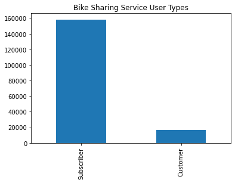

```python
# Visualize the types of users in the dataset
df_new['user_type'].value_counts().plot.bar().set_title('Bike Sharing Service User Types');
```

> **The number of subscribers is way more than customers**.

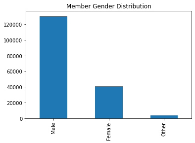

```python
# Visualize the various gender of members in the dataset
df_new['member_gender'].value_counts().plot.bar().set_title('Member Gender Distribution');
```

> **Male Bikers are 3 time more than Female Bikers**

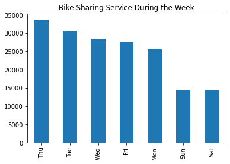

```python
# Visualize the various gender of members in the dataset
df_new['start_time_dayofweek'].value_counts().plot.bar().set_title('Bike Sharing Service During the Week');
```

> **Thursdays appears to be the day with the most biking activity. This is followed by Tuesday and then Wednesday.**

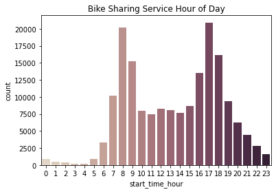

```python
# Plot the hour of the day riders used the bike sharing service
sns.countplot(data = df_new, x = 'start_time_hour',
              palette="ch:.25").set_title('Bike Sharing Service Hour of Day');
```

> **We observe from the data that the peak hours were registered mostly at 8am and 5pm. This corresponds to the rush hours when people commute to and from work.**

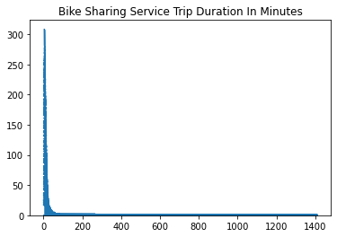

```python
#Plot the duration in minutes of the data using an area plot
df_new['duration_min'].value_counts().plot.area().set_title('Bike Sharing Service Trip Duration In Minutes');
```

> **Quite a number of the trip duration falls below 100 minutes. We can exclude outlier trips above 100 minutes to better get a sense of our data.**

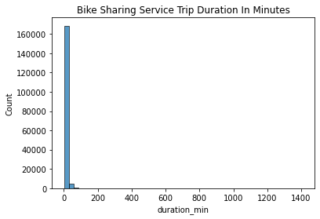

```python
#Plot the duration in minutes of the data using a histogram
sns.histplot(data = df_new, x = 'duration_min',
             bins=50).set_title('Bike Sharing Service Trip Duration In Minutes');
```

> **For the most part, the overall trip duration of riders falls below 100 minutes.**

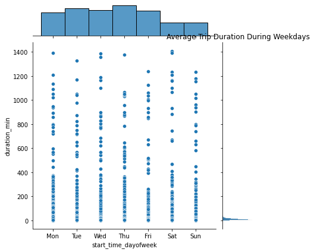

```python
#Jointly visualize the average trip duration during weekdays
sns.jointplot(data=df_new, x='start_time_dayofweek', y='duration_min')
plt.title('Average Trip Duration During Weekdays');
```

> This corrobates the previous visualizations in the sence that most trips lasted below 60 mins and Tuesday and Thursday had the most traffic.

```python
# Get a sense of the age distribution of members and plot the data
df_new.member_age.describe()
```

```
count    174952.000000
mean         36.196865
std          10.118731
min          20.000000
25%          29.000000
50%          34.000000
75%          41.000000
max         143.000000
Name: member_age, dtype: float64
```

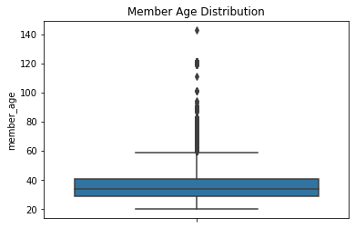

```python
# Use seaborn's boxplot to plot the age distribution of members in the dataset
sns.boxplot(data = df_new,
            y='member_age').set_title('Member Age Distribution');
```

> **From the data, we see a number of outliers from above age 60. To clean up the data, we would only use member ages below 60.**

```python
# Remove the outliers and keep only members with ages below 60
df_new = df_new[df_new.member_age <= 60]
```

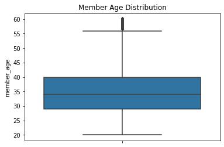

```python
sns.boxplot(data = df_new,
            y='member_age').set_title('Member Age Distribution');
```

> **This looks clean and gives us a better distribution of the meber ages.**

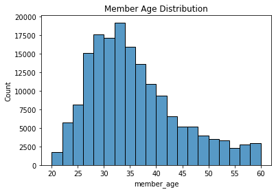

```python
# Plot a histogram with the distribution of member ages
sns.histplot(data = df_new,
             x='member_age', bins=20).set_title('Member Age Distribution');
```

> **The majority of riders fall between the ages of 20 to 40. This is understandable as it happens to be the active age bracket for the two user types in our dataset.**

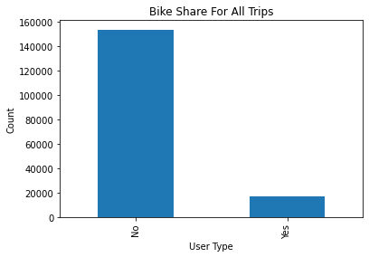

```python
# Visualise the data for riders who share bike trips and those who don't share trips.
df_new['bike_share_for_all_trip'].value_counts().plot.bar().set_title('Bike Share For All Trips')
plt.xlabel('User Type')
plt.ylabel('Count');
```

### Discuss the distribution(s) of your variable(s) of interest. Were there any unusual points? Did you need to perform any transformations?

> - From our analysis, we see that the number of riders who shared their triped is dwarfed by those who did not share their trips.
> - The number of trips peaked at around 8am in the morning and 5pm in the evening. Also, Tuesdays and Thursdays saw the highest number of activity.
> - There are more male riders than female riders as seen in our dataset.
> - The variable **member_age** had outlier above the age of 60. To better analyse our date, all member ages above 60 were dropped.

### Of the features you investigated, were there any unusual distributions? Did you perform any operations on the data to tidy, adjust, or change the form of the data? If so, why did you do this?

> I created new variables were created such as start_time_dayoftheweek, start_time_hour and the duration in minutes to help with performing additional analysis on the data.

## Bivariate Exploration

> I would create visualizations to show potential relationships between the variables in the dataset

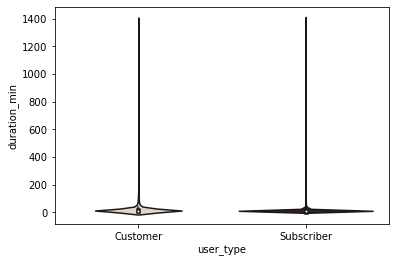

```python
# Plot a violin plot to investigate how the trip duration distribution between customers and subscribers
sns.violinplot(x=df_new['user_type'],
               y=df_new['duration_min'], palette="ch:.25");
```

> The variable duration_min has a lot of noise above 60 minutes. All trip durations above 60 mins would be dropped to better analyse the data.

```python
# Clean up the data and only plot trip durations that were either below 60 minutes or on the 60 minutes mark
df_new = df_new.query('duration_min <= 60')
```

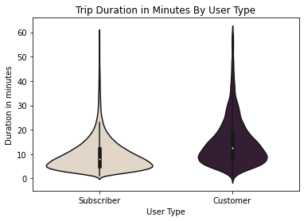

```python
# Plot a violin plot to investigate how the trip duration distribution between customers and subscribers
sns.violinplot(x=df_new['user_type'], y=df_new['duration_min'],
               palette="ch:.25").set_title('Trip Duration in Minutes By User Type')
plt.xlabel('User Type')
plt.ylabel('Duration in minutes')
plt.show();
```

> This looks better and we see that subscribers have shorter trips compared to customers whose trips lasted for longer periods of time.

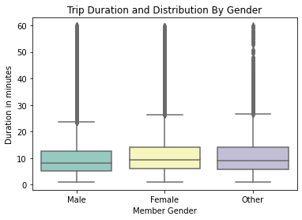

```python
# Plot a boxplot to investigate how the trip duration distribution by gender
sns.boxplot(x=df_new['member_gender'], y=df_new['duration_min'],
            palette="Set3").set_title('Trip Duration and Distribution By Gender')
plt.xlabel('Member Gender')
plt.ylabel('Duration in minutes')
plt.show();
```

> Not so much in terms of the disparities but we see members of the female gender tend to take longer rides as compared to the male gender. This is also corroborated by the higher median and Interquartile range (IQR) for the female gender as seen on the plot.

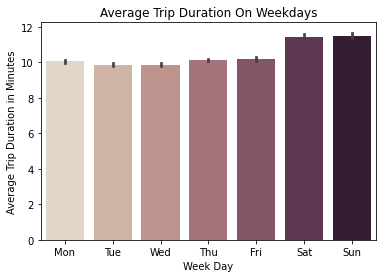

```python
# Plot a bar plot to investigate how the trip duration distribution by day of the week
sns.barplot(x=df_new['start_time_dayofweek'], y=df_new['duration_min'],
            palette="ch:.25").set_title('Average Trip Duration On Weekdays')
plt.xlabel('Week Day')
plt.ylabel('Average Trip Duration in Minutes')
plt.show();
```

> As expected, Saturdays and Sundays were days that registered the longest trips. This is not surprising since it is weekend and most people don't work on these days.

[figure not shown]

```python
# Plot a bar plot to investigate how the trip duration distribution by member age
sns.barplot(x=df_new['start_time_dayofweek'], y=df_new['member_age'],
            palette="ch:.25").set_title('Average Trip Duration On Weekdays')
plt.xlabel('Member Age')
plt.ylabel('Average Trip Duration in Minutes')
plt.show();
```

> Weekday riders appear to be slightly older than weekend riders. This may not be farfetched as most working class people who commute to work during weekdays utilize the bikes than on weekends.

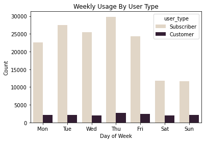

```python
# Visualize the weekly usage by customers and subscribers
sns.countplot(data = df_new, x='start_time_dayofweek',
              hue='user_type', palette="ch:.25")
plt.xlabel('Day of Week')
plt.ylabel('Count')
plt.title('Weekly Usage By User Type')
plt.show();
```

> There were more subscriber riders overall when compared to customers. The weekend drop also indicate many of the subscribers commute to work during weekdays.

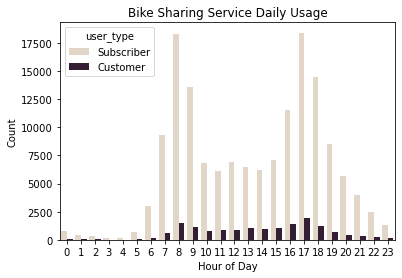

```python
# Visualize the daily usage by hour of day
sns.countplot(data=df_new, x='start_time_hour',
              hue='user_type', palette="ch:.25");
plt.xlabel('Hour of Day')
plt.ylabel('Count')
plt.title('Bike Sharing Service Daily Usage');
```

> Again, the peak at 8am and 5pm corresponds with the work hours during the day. Subscribers most likely rode suring those hours to and from work.

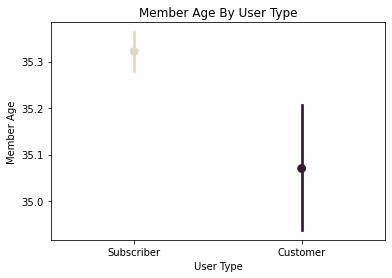

```python
# Using a point plot, visualize the age of customers and subscribers
sns.pointplot(data=df_new, x='user_type',
              y='member_age', palette="ch:.25", linestyles='');
plt.xlabel('User Type');
plt.ylabel('Member Age');
plt.title('Member Age By User Type');
```

> Subscribers were older than customers. This is understandable since we can deduce that most riders belonged to the working class.

## Multivariate Exploration

```python
# Check for correlation in the dataset
df_new.corr()
```

|  | duration_sec | start_station_id | start_station_latitude | start_station_longitude | end_station_id | end_station_latitude | end_station_longitude | bike_id | member_birth_year | start_time_hour | member_age | duration_min |
| --- | --- | --- | --- | --- | --- | --- | --- | --- | --- | --- | --- | --- |
| duration_sec | 1.000000 | -0.031835 | 0.033792 | -0.118818 | -0.016567 | 0.035596 | -0.119881 | 0.035552 | -0.012394 | 0.011475 | 0.012394 | 1.000000 |
| start_station_id | -0.031835 | 1.000000 | -0.194718 | 0.467084 | 0.339836 | -0.183810 | 0.474311 | -0.070186 | 0.129527 | 0.011178 | -0.129527 | -0.031835 |
| start_station_latitude | 0.033792 | -0.194718 | 1.000000 | -0.678084 | -0.184436 | 0.990291 | -0.683711 | 0.051389 | -0.089378 | -0.019121 | 0.089378 | 0.033792 |
| start_station_longitude | -0.118818 | 0.467084 | -0.678084 | 1.000000 | 0.488697 | -0.682654 | 0.992566 | -0.145430 | 0.151129 | 0.054246 | -0.151129 | -0.118818 |
| end_station_id | -0.016567 | 0.339836 | -0.184436 | 0.488697 | 1.000000 | -0.202453 | 0.478410 | -0.059700 | 0.128601 | 0.093683 | -0.128601 | -0.016567 |
| end_station_latitude | 0.035596 | -0.183810 | 0.990291 | -0.682654 | -0.202453 | 1.000000 | -0.685157 | 0.050953 | -0.089433 | -0.035878 | 0.089433 | 0.035596 |
| end_station_longitude | -0.119881 | 0.474311 | -0.683711 | 0.992566 | 0.478410 | -0.685157 | 1.000000 | -0.147282 | 0.151718 | 0.034661 | -0.151718 | -0.119881 |
| bike_id | 0.035552 | -0.070186 | 0.051389 | -0.145430 | -0.059700 | 0.050953 | -0.147282 | 1.000000 | 0.027973 | 0.014807 | -0.027973 | 0.035552 |
| member_birth_year | -0.012394 | 0.129527 | -0.089378 | 0.151129 | 0.128601 | -0.089433 | 0.151718 | 0.027973 | 1.000000 | 0.064933 | -1.000000 | -0.012394 |
| start_time_hour | 0.011475 | 0.011178 | -0.019121 | 0.054246 | 0.093683 | -0.035878 | 0.034661 | 0.014807 | 0.064933 | 1.000000 | -0.064933 | 0.011475 |
| member_age | 0.012394 | -0.129527 | 0.089378 | -0.151129 | -0.128601 | 0.089433 | -0.151718 | -0.027973 | -1.000000 | -0.064933 | 1.000000 | 0.012394 |
| duration_min | 1.000000 | -0.031835 | 0.033792 | -0.118818 | -0.016567 | 0.035596 | -0.119881 | 0.035552 | -0.012394 | 0.011475 | 0.012394 | 1.000000 |

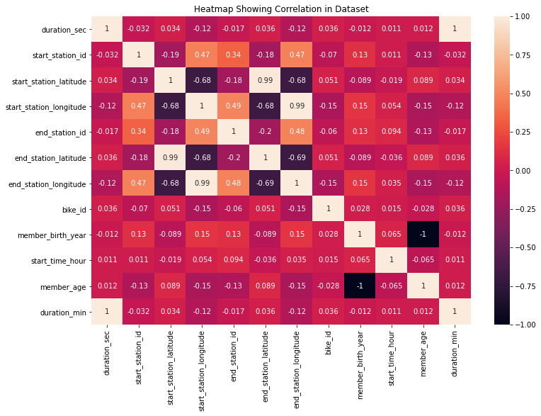

```python
# Create a heatmap showing the correlation in the dataset
corr = df_new.corr()
plt.figure(figsize=(12,8))
sns.heatmap(corr, annot=True).set_title('Heatmap Showing Correlation in Dataset');
```

> The heatmap helps to narrow down on the variables that are correlated in the dataset.

```python
df_new.columns
```

```
Index(['duration_sec', 'start_time', 'end_time', 'start_station_id',
       'start_station_name', 'start_station_latitude',
       'start_station_longitude', 'end_station_id', 'end_station_name',
       'end_station_latitude', 'end_station_longitude', 'bike_id', 'user_type',
       'member_birth_year', 'member_gender', 'bike_share_for_all_trip',
       'start_time_dayofweek', 'start_time_hour', 'member_age',
       'duration_min'],
      dtype='object')
```

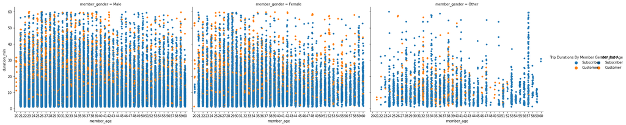

```python
#Visualize the trip durations by member gender and age
g = sns.catplot(x='member_age', y='duration_min', hue='user_type', aspect=1.4,
            col='member_gender', kind="strip", data=df_new)
g.add_legend(title='Trip Durations By Member Gender and Age', adjust_subtitles=True);
```

> This visualization looks clumsy and does not present the data in a reader friendly manner.

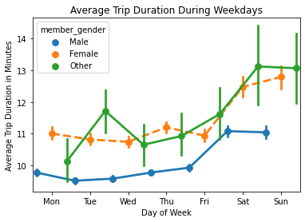

```python
#Visualize the average trip duration during weekdays by member gender
sns.pointplot(data=df_new, x='start_time_dayofweek', y='duration_min',
              hue='member_gender', dodge=0.8, linestyles=["-", "--", "-"],);
plt.xlabel('Day of Week');
plt.ylabel('Average Trip Duration in Minutes');
plt.title('Average Trip Duration During Weekdays');
```

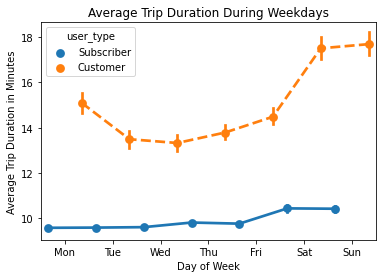

```python
#Visualize the average trip duration during weekdays between user type
sns.pointplot(data=df_new, x='start_time_dayofweek', y='duration_min',
              hue='user_type', dodge=0.7, linestyles=["-", "--"],);
plt.xlabel('Day of Week');
plt.ylabel('Average Trip Duration in Minutes');
plt.title('Average Trip Duration During Weekdays');
```

> Customers had an overall longer duration of trips during weekdays. However, both subscribers and customers experienced increase in trip duration during weekends.

### Were there any interesting or surprising interactions between features?

> The univariate, bivariate and multivariate plots presented insight into the data and complemented each other in the sense that findings in one completed earlier findings in others.